# Advanced models

# 1 Getting started

## 1.1 Required packages

```r
library(tidyverse)   # THE library for data science
library(highcharter) # For interactive plots
library(WDI)         # For World Bank data
library(openxlsx)    # A cool package to deal with Excel files/formats
library(quantmod)    # Package for financial data extraction
library(tsibble)     # TS with dataframes framework
library(fable)       # Package for time-series models & predictions
library(feasts)      # Package for time-series analysis
library(forecast)    # Another package for TS (forecasting)
library(tseries)     # Simple package for time-series tests
library(plotly)      # For 3D graphs
library(mvtnorm)     # For multivariate Gaussian distributions
library(crypto2)     # For cryto data
library(ggsci)       # For color palettes
library(rugarch)     # For GARCH models
library(fGarch)      # For GARCH models
set.seed(42)         # Random seed

impute <- function(v, n = 6){     # Imputation function
  for(j in 1:n){
    ind <- which(is.na(v))
    if(length(ind)>0){
      if(ind[1]==1){ind <- ind[-1]}
      v[ind] <- v[ind-1]
    }
  }
  return(v)
}
```

## 1.2 Fetching some (crypto) data

```r
coins <- crypto_list()
c_info <- crypto_info(coin_list = coins, limit = 30)
```

```
❯ Scraping crypto info
```

```
❯ Processing crypto info
```

```r
coin_names <- c("Bitcoin", "Ethereum", "Tether USDt", "BNB", "USDC", "Solana")
coin_hist <- crypto_history(coins |> dplyr::filter(name %in% coin_names),
                            start_date = "20170101",
                            end_date = "20251206")
```

```
❯ Scraping historical crypto data
```

```
❯ Processing historical crypto data
```

```
Coin USDC does not have data available! Cont to next coin.

Coin Solana does not have data available! Cont to next coin.

Coin Solana does not have data available! Cont to next coin.
```

```r
coin_hist <- coin_hist |>  # Timestamps are at midnight, hence we add a day.
  dplyr::mutate(date = 1 + as.Date(as.POSIXct(timestamp, origin="1970-01-01")))
coin_hist <- coin_hist |>
  group_by(name) |>
  mutate(return = close / lag(close) - 1 ) |>
  ungroup()
```

# 2 ARCH-type models

## 2.1 Realized volatility

Then, let’s have a look at volatility. It’s measured as

$$v_t=\sqrt{\frac{1}{T-1}\sum_{s=1}^T(r_{t-s}-\bar{r})^2},$$
where $\bar{r}$ is the mean return in the sample of $T$ observations. Below, we use an optimized (C++-based function) to compute it via rolling standard deviation over 20 days.

```r
library(RcppRoll)
coin_hist <- coin_hist |>
  group_by(name) |>
  na.omit() |>
  mutate(real_vol_20 = roll_sd(return, n = 20, fill = NA, na.rm = T))
```

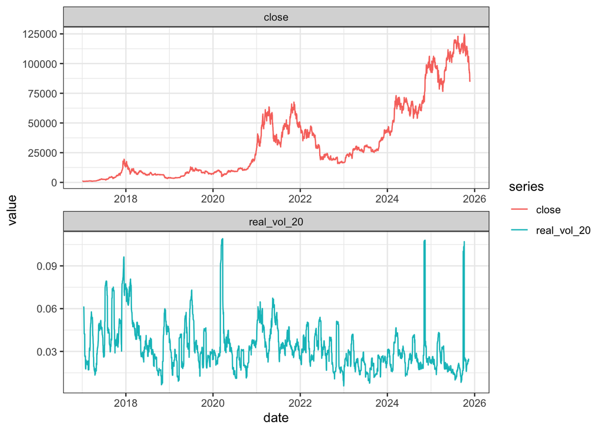

```r
coin_hist |>
  filter(name == "Bitcoin") |>
  pivot_longer(all_of(c("close", "real_vol_20")), names_to = "series", values_to = "value") |>
  ggplot(aes(x = date, y = value, color = series)) + geom_line() + theme_bw() +
  facet_wrap(vars(series), nrow = 2, scales = "free")# + scale_y_log10()
```

Now let’s have a look a the autocorrelation of the volatility: it’s highly persistent.

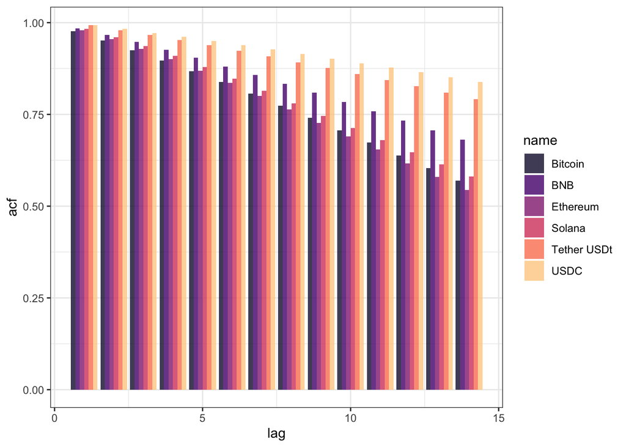

```r
crypto_acf <- coin_hist |>
  na.omit() %>%
  split(.$name) %>%
  map(~acf(.$real_vol_20, plot = F)) %>%
  map_dfr(
    ~data.frame(lag = .$lag,
                acf = .$acf,
                ci = qnorm(0.975)/sqrt(.$n.used)
    ), .id = "name")
crypto_acf |>
  filter(lag > 0, lag < 15) |>
  ggplot(aes(x = lag, y = acf, fill = name)) +
  geom_col(position = "dodge", alpha = 0.8) + theme_bw() +
  scale_fill_viridis_d(option = "magma", end = 0.9, begin = 0.1)
```

Hence, in practice, simple autoregressive models can be too limited because some variables are not *exactly* stationary.

The realized volatility is based on **past** returns. But markets (**equity** mostly) have another very cool and forward-looking indicator called the [**VIX**](https://www.cboe.com/tradable_products/vix/). The VIX is slightly different, because it is based on forward-looking option prices (taking their implied volatilities over specific horizons). Still, it is linked (empirically) to the traditional volatility.

Let’s have a look below.

```r
min_date <- "1998-01-01"                 # Starting date
max_date <- "2025-11-07"                 # Ending date
getSymbols("^VIX", src = 'yahoo',        # The data comes from Yahoo Finance
           from = min_date,              # Start date
           to = max_date,                # End date
           auto.assign = TRUE,
           warnings = FALSE)
```

```
[1] "VIX"
```

```r
VIX <- VIX |> as.data.frame() |>
  rownames_to_column("date") |>
  dplyr::mutate(date = as.Date(date))
head(VIX,7)                                   # Have a look at the result!
```

```
        date VIX.Open VIX.High VIX.Low VIX.Close VIX.Volume VIX.Adjusted
1 1998-01-02    24.34    24.93   23.42     23.42          0        23.42
2 1998-01-05    24.11    25.02   23.02     24.36          0        24.36
3 1998-01-06    25.20    25.97   24.87     25.66          0        25.66
4 1998-01-07    26.15    27.43   25.07     25.07          0        25.07
5 1998-01-08    26.24    26.70   25.62     26.01          0        26.01
6 1998-01-09    25.79    29.35   25.69     28.69          0        28.69
7 1998-01-12    28.69    31.08   28.02     28.02          0        28.02
```

```r
vix_chart <- VIX |> dplyr::select(VIX.Close)
rownames(vix_chart) <- VIX |> dplyr::pull(date)
highchart(type = "stock") %>%
    hc_title(text = "Evolution of the VIX") %>%
    hc_add_series(as.xts(vix_chart)) %>%
    hc_tooltip(pointFormat = '{point.y:.3f}')
```

[interactive chart not shown]

We clearly see that the series exhibits some moments of extreme activity and its distribution is not the same through time. This is referred to as “*clusters of volatility*”.

## 2.2 Some theory

Therefore, we also need to introduce models that allow for this type of feature. In 1982, Robert Engle proposed such a model, called [**ARCH**](https://www.jstor.org/stable/1912773) for “*AutoRegressive Conditional Heteroskedasticity*”, which was generalized in 1986 to [**GARCH**](https://www.sciencedirect.com/science/article/abs/pii/0304407686900631) models. Engle obtained the Nobel Prize in economics in part for this contribution.

The idea is to work with the innovations, $e_t$ and to specify them a bit differently, i.e., like this: $e_t=\sigma_t z_t$, where $\sigma_t$ is going to be a changing standard deviation and $z_t$ is a simple white noise. What matters is that the vol term is modelled as
$$\sigma^2_t = a+\sum_{j=1}^pd_j\sigma^2_{t-j} + \sum_{k=1}^qb_ke^2_{t-k},$$
hence, the value of $\sigma_t^2$ depends both on its past and on the past of squared innovations.

There have been MANY extension to these models: T-GARCH, E-GARCH, etc. See for instance [GARCH models: structure, statistical inference and financial applications](https://onlinelibrary.wiley.com/doi/book/10.1002/9781119313472).

## 2.3 Examples: estimation

There are many packages for GARCH estimation. We propose two: [**ruGARCH**](https://cran.r-project.org/web/packages/rugarch/index.html) and [**fGARCH**](https://cran.r-project.org/web/packages/fGarch/index.html).

In **fGARCH**, the model is:

$$\sigma_t^2 = \omega + \alpha e_{t-1} + \beta \sigma_{t-1}^2.$$
In the output, there are some additional parameters that allow to propose a more general model:

- **shape** is the shape parameter of the conditional distribution.
- **skew** is the skewness parameter of the conditional distribution.
- **delta** a numeric value, the exponent delta of the variance recursion, fixed at 2 usually.

$\delta$ values other than 2 come from P-GARCH models:

$$\begin{align}
\varepsilon_t & = \sigma_t z_t, \qquad z_t \overset{\text{i.i.d.}}{\sim} \text{Skew}(\text{shape},\text{skew}), \\
\sigma_t^{\delta}
&= \omega
+ \sum_{i=1}^{q} \alpha_i\bigl(|\varepsilon_{t-i}| - \gamma_i \varepsilon_{t-i}\bigr)^{\delta}
+ \sum_{j=1}^{p} \beta_j\,\sigma_{t-j}^{\delta},
\end{align}$$

The distribution is the [Skewed Generalized Error Distribution](https://en.wikipedia.org/wiki/Skewed_generalized_t_distribution) that allows for more flexibility than the simple Gaussian law. It nests many simpler distribution, like the Cauchy, Laplace, GED and Student laws for instance.

```r
fit_f <- garchFit(formula = ~garch(1,1),
         data = coin_hist |>
           filter(name == "Bitcoin") |>
           pull(return),
         trace = F)
fit_f
```

```
Title:
 GARCH Modelling

Call:
 garchFit(formula = ~garch(1, 1), data = pull(filter(coin_hist,
    name == "Bitcoin"), return), trace = F)

Mean and Variance Equation:
 data ~ garch(1, 1)
<environment: 0x13f4c1970>
 [data = pull(filter(coin_hist, name == "Bitcoin"), return)]

Conditional Distribution:
 norm

Coefficient(s):
        mu       omega      alpha1       beta1
1.2641e-03  8.8345e-05  1.0240e-01  8.3464e-01

Std. Errors:
 based on Hessian

Error Analysis:
        Estimate  Std. Error  t value Pr(>|t|)
mu     1.264e-03   5.257e-04    2.405   0.0162 *
omega  8.834e-05   1.090e-05    8.109 4.44e-16 ***
alpha1 1.024e-01   1.185e-02    8.638  < 2e-16 ***
beta1  8.346e-01   1.578e-02   52.907  < 2e-16 ***
---
Signif. codes:  0 '***' 0.001 '**' 0.01 '*' 0.05 '.' 0.1 ' ' 1

Log Likelihood:
 7069.725    normalized:  1.972029

Description:
 Fri Nov 28 18:51:55 2025 by user:
```

Now, with **rugarch**…

```r
spec <- ugarchspec()
fit_r <- ugarchfit(data = coin_hist |>
                     filter(name == "Bitcoin") |>
                     na.omit() |>
                     pull(return),
                   spec = spec)
fit_r@fit$coef
```

```
           mu           ar1           ma1         omega        alpha1
 1.311848e-03 -4.063468e-01  3.703754e-01  8.699087e-05  1.005051e-01
        beta1
 8.367663e-01
```

With both libraries, it is possible to make predictions.

```r
predict(fit_f, n.ahead = 5)
```

```
  meanForecast  meanError standardDeviation
1  0.001264133 0.03103033        0.03103033
2  0.001264133 0.03147381        0.03147381
3  0.001264133 0.03188377        0.03188377
4  0.001264133 0.03226319        0.03226319
5  0.001264133 0.03261471        0.03261471
```

```r
ugarchforecast(fit_r, n.ahead = 3)
```

```
*------------------------------------*
*       GARCH Model Forecast         *
*------------------------------------*
Model: sGARCH
Horizon: 3
Roll Steps: 0
Out of Sample: 0

0-roll forecast [T0=1979-10-07]:
      Series   Sigma
T+1 0.001434 0.02882
T+2 0.001262 0.02942
T+3 0.001332 0.02997
```

The values are quite close!

# 3 Vector Auto-Regression

## 3.1 The VAR(1) model

Now we are switching to full multivariate mode! With the Vector Auto-Regression (VAR). It is written as:

$$X_t = \mu + A X_{t-1} + \varepsilon_t,
\qquad \varepsilon_t \sim \text{i.i.d. } (0,\Sigma_\varepsilon),$$
with $X_t \in \mathbb{R}^k, \mu \in \mathbb{R}^k, A \in \mathbb{R}^{k \times k}$.

If the VAR(1) is stable (all eigenvalues of $A$ satisfy $|\lambda_i(A)|<1$), the **unconditional mean** exists and is given by
$$\mathbb{E}[X_t] = \bar{X} = (I - A)^{-1}\mu.$$

Next, let $\Gamma_0 = \mathbb{V}(X_t)$, it must satisfy
$$\Gamma_0 = A \Gamma_0 A^\top + \Sigma_\varepsilon.$$

Next, define the lag-$h$ autocovariance matrix:
$$\Gamma_h = \text{Cov}(X_t, X_{t-h}) = \mathbb{E}[X_t X_{t-h}^\top].$$

Using for simplicity $X_t = A X_{t-1} + \varepsilon_t$ (the constant terms do not affect the covariances):
$$\Gamma_h = \text{Cov}(A X_{t-1} + \varepsilon_t, X_{t-h}) = A \text{Cov}(X_{t-1}, X_{t-h}) + \underbrace{\text{Cov}(\varepsilon_t, X_{t-h})}_{=0}
= A \Gamma_{h-1}$$

By recursion, we obtain:
$$\Gamma_h = A^h \Gamma_0, \quad h \ge 0.$$

## 3.2 The VAR(p) Model

A Vector Autoregression of order $p$, denoted VAR($p$), models a $k$-dimensional time series vector $\mathbf{X}_t = (X_{1,t}, \dots, X_{k,t})^\top$ as:

$$\mathbf{X}_t
= \mathbf{c} + A_1 \mathbf{X}_{t-1} + A_2 \mathbf{X}_{t-2} + \cdots + A_p \mathbf{X}_{t-p} + \mathbf{e}_t,$$

where:

- $\mathbf{X}_t$ is a $k \times 1$ vector of endogenous variables,
- $\mathbf{c}$ is a $k \times 1$ vector of intercept terms,
- $A_i$ are $k \times k$ coefficient matrices,
- $\mathbf{e}_t$ is a $k \times 1$ vector of innovations (reduced-form errors).

**Error term assumptions**: the innovations satisfy

$$\mathbf{u}_t \sim (0, \Sigma_u),$$

where $\Sigma_u$ is a symmetric positive definite $k \times k$ covariance matrix, allowing contemporaneous correlation across equations.

## 3.3 Empirics

```r
wb_raw <- WDI(                              # World Bank data
  indicator = c(
    "labor" = "SL.TLF.TOTL.IN",             # Labor force (# individuals)
    "savings_rate" = "NY.GDS.TOTL.ZS",      # Savings rate (% GDP)
    "inflation" = "FP.CPI.TOTL.ZG",         # Inflation rate
    "trade" = "NE.TRD.GNFS.ZS",             # Trade as % of GDP
    "pop" = "SP.POP.TOTL",                  # Population
    "pop_growth" = "SP.POP.GROW",           # Population growth
    "capital_formation" = "NE.GDI.TOTL.ZS", # Gross capital formation (% GDP)
    "gdp_percap" = "NY.GDP.PCAP.CD",        # GDP per capita
    "RD_percap" = "GB.XPD.RSDV.GD.ZS",      # R&D per capita
    "educ_level" = "SE.SEC.CUAT.LO.ZS",     # % pop reachiing second. educ. level
    "educ_spending" = "SE.XPD.TOTL.GD.ZS",  # Education spending (%GDP)
    "nb_researchers" = "SP.POP.SCIE.RD.P6", # Nb researchers per million inhab.
    "debt" = "GC.DOD.TOTL.GD.ZS",           # Central gov. debt (% of GDP)
    "gdp" = "NY.GDP.MKTP.CD"                # Gross Domestic Product (GDP)
  ),
  extra = TRUE,
  start = 1960,
  end = 2024) |>
  mutate(across(everything(), as.vector)) |>
  select(-status, -lending, -iso2c, -iso3c) |>
  filter(region != "Aggregates", income != "Aggregates") |>
  arrange(country, year) |>
  group_by(country) |>
  mutate(across(everything(), impute)) |>
  mutate(gdp_growth = gdp_percap/dplyr::lag(gdp_percap) - 1, .before = "region") |>
  ungroup() |>
  filter(lastupdated == max(lastupdated)) |>
  arrange(country, year)
```

# 4 A primer on prediction

## 4.1 Training/testing & co

The key idea is **backtest**: you have to put yourself in the shoes of someone living in the past. By this we mean, without knowledge of the future. To do this, you need to consider a loop that spans different dates in the past. At each point in time $t$ you:

1. extract the data available at time $t$;
2. build a predictive model;
3. make some prediction based on the currently available data;
4. evaluate the accuracy of the prediction thanks to the (future) realized values

## 4.2 Some code

Models (and people) often focus on loss (objective) functions.  
In finance, we usually try to forecast returns, hence the loss function is the (root-) **Mean Squared Error**:

$$\text{MSE} = \frac{1}{T} \sum_{t=1}^T (r_t-\tilde{r}_t)^2,$$

where $r_t$ is the realized return and $\tilde{r}_t$ is the model return. Assuming predictions are unbiased $(\mathbb{E}[r_t]=\mathbb{E}[\tilde{r}_t])$, then (after some math…)

$$\text{MSE} = \mathbb{E}[(r_t - \tilde{r}_t)^2]=\mathbb{V}[r_t]+\mathbb{V}[\tilde{r}_t]-2\text{Cov}(r_t, \tilde{r}_t)$$

**Question**: which of these terms matter the most?

# 5 Advanced temporal models

## 5.1 (Feedforward) neural networks

A few images help explain how simple NNs work.

First, the **structure**. The network takes an input which is then processed via many multiplications, additions and activations.  
At the very end, we get the output. It can be a simple number, but could also be more complex (vector, matrix, etc.).

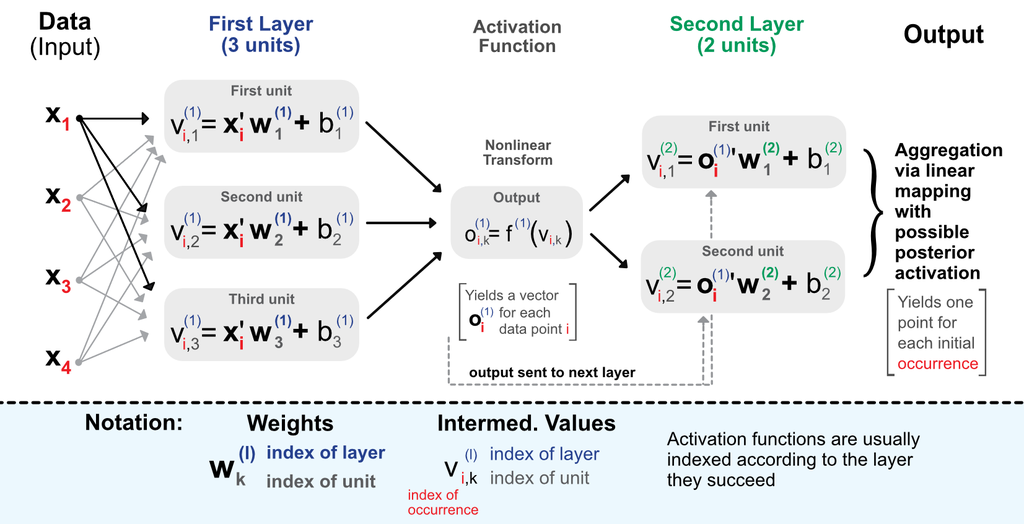

The intermediate **activation** functions are there to break the linearity. A few examples below:

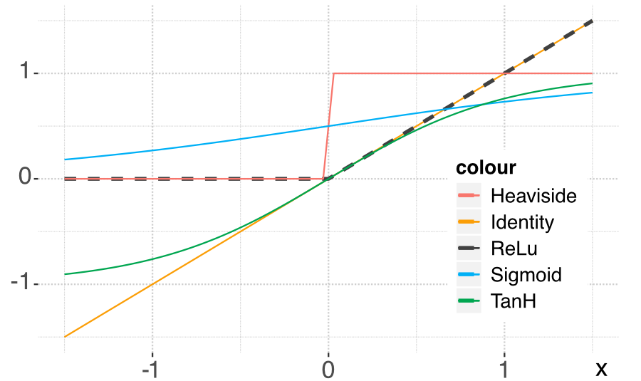

Next, the **training**. This phase is intended to determine “good” parameter values. Obviously, the “best” parameters would be ideal, but they are out of reach (the problem is too complex).

The core idea is **gradient descent**: we seek to minimize a loss function (e.g., the MSE) and this depends on the derivative:

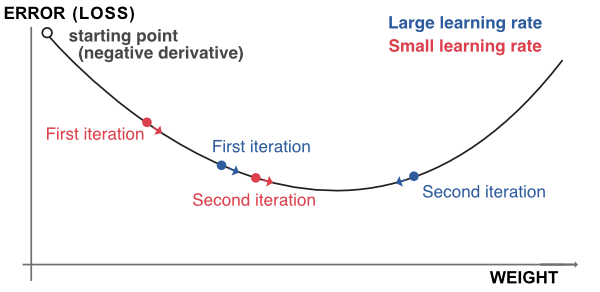

Now, there is a very interesting process called **backpropagation** that involves lots of computations of derivatives (skipped here):

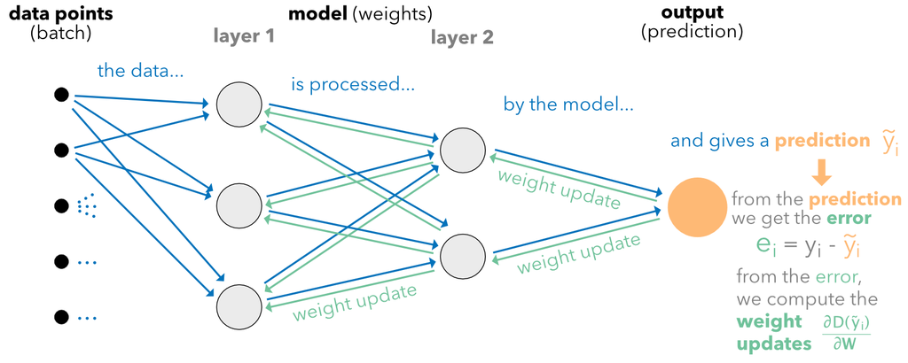

In the end, the parameters (weights) of the model are locally optimal.  
But they depend on the **training sample**: whether they work well out-of-sample (on testing sets) is another question.  
If yes, the model is said to **generalize** well. That’s the great quest of machine learning.

## 5.2 Recurrent networks